# CSR Quarterly Engagement Analysis

iwc95

12/11/2019

## Synopsis

This document will explain the methodology for the quarterly analysis for the engagements of Dell’s CSR team. This team is responsible for ensuring that regulatory, procurement, and environmental needs are met through Dell’s corporate office. Each quarter, a number of Request for Proposals (RFPs), Customer Engagements (CE), and Other items are tracked. Further, each of these engagements falls under a certain category and pertains to a variety of predisposed tags associated with that category. In this report, I will walk through this algorithm and provide meaningful analysis and data visualization for the CSR tracker.

# Getting data into R

First, the tracker will need to be downloaded from the CDR OneDrive. Once the latest version has been dowloaded, open in excel and ensure that the data is clean and ready for analysis in R. Once that’s done, load the necessary packages you will need in R and load in the tracker.

```r
library(tidyverse)
library(tidytext)
library(readxl)
library(openxlsx)
library(stringr)
library(readr)

d <- "trackerdata2.xlsx" ##Import the tracker data, as updated as possible
tracker <- read_excel(d,sheet = 1, col_names = TRUE)
head(tracker)
```

```
## # A tibble: 6 x 18
##   Name_of_Customer AE    Region Country Form  Category Date_Received
##   <chr>            <chr> <chr>  <chr>   <chr> <chr>    <dttm>
## 1 Quantum          N/A   Ameri… USA     Ques… Respons… 2019-10-28 00:00:00
## 2 University of W… Fab_… Ameri… Canada  Ques… General… 2019-10-22 00:00:00
## 3 Murray & Roberts Anne… EMEA   South … Ques… Diversi… 2019-10-17 00:00:00
## 4 General Electric Shar… APJ    Malays… Ques… General… 2019-10-22 00:00:00
## 5 HSBC             Lee … EMEA   United… Indi… Account… 2019-10-23 00:00:00
## 6 Solvay           Yass… EMEA   France  Ques… General… 2019-10-23 00:00:00
## # … with 11 more variables: Date_Responded <dttm>, Responder <chr>,
## #   Escalation <chr>, Tags <chr>, ID <dbl>, `Engagement Score` <dbl>,
## #   Deal_size <dbl>, `CSR % of Deal` <chr>, `SFDC ID` <lgl>, `Item
## #   Type` <chr>, Path <chr>
```

The tracker is now loaded in with 3237 observations and 18 variables. This means that though 2014 to Q3 of FY20, there were 3,237 entries. While 18 variables explains how many columns are in the original tracker. You can refine the tracker by filtering only the columns that are of interest in this anlysis:

```r
##Refine to make data more manageable
refine_tracker <- select(tracker, Name_of_Customer, Region, Form, Category, Date_Received, Escalation, Tags)

head(refine_tracker)
```

```
## # A tibble: 6 x 7
##   Name_of_Customer Region Form  Category Date_Received       Escalation
##   <chr>            <chr>  <chr> <chr>    <dttm>              <chr>
## 1 Quantum          Ameri… Ques… Respons… 2019-10-28 00:00:00 1
## 2 University of W… Ameri… Ques… General… 2019-10-22 00:00:00 2
## 3 Murray & Roberts EMEA   Ques… Diversi… 2019-10-17 00:00:00 3
## 4 General Electric APJ    Ques… General… 2019-10-22 00:00:00 2
## 5 HSBC             EMEA   Indi… Account… 2019-10-23 00:00:00 3
## 6 Solvay           EMEA   Ques… General… 2019-10-23 00:00:00 2
## # … with 1 more variable: Tags <chr>
```

This makes the data more manageable, as these are the variables that we are interested in. Tags is not important until the data mining section, which is last.

# Setting time frames

Next, it is important that the analysis is being done for the time frame that is requested. Usually, it is a quarter to quarter analysis, however, lately, a full analysis of a fiscal year (2-1-XX, 1-31-XX) has been requested. Filtering the Date receieved column allows this parsing to take place:

```r
y19 <- filter(refine_tracker, Date_Received >= "2019-02-01" & Date_Received <= "2020-01-31")

y19q1 <- filter(refine_tracker, Date_Received >= "2019-02-01" & Date_Received <= "2019-04-30")
y19q2 <- filter(refine_tracker, Date_Received >= "2019-05-01" & Date_Received <= "2019-07-31")
y19q3 <- filter(refine_tracker, Date_Received >= "2019-08-01" & Date_Received <= "2019-10-31")
y19q4 <- filter(refine_tracker, Date_Received >= "2019-11-01" & Date_Received <= "2020-01-31")
```

As the years and quarter changes, modification to the above code may need altered. Parsing the data this way allows one to do an analysis for just one of the quarters, as well as for the year-to-date fiscal year results.

# Components of Tracker

There are three components to the tracker, RFPs, Customer Engagements, and Other (usually Awards or ‘Wins’). All of these are tracked together in the CSR tracker, however, each have a different intepretation for what kind of engagement took place. For this reason, the RFPs will be analyzed seperately, followed by the CEs, and finally Other will be looked at. Typically, RFPs comprise most of the entries, while CEs are only a portion of the tracked items. For this report, FY20 data is incomplete, as only quarter 1-3 have taken place. The year can be adjusted by changing the dates as well as the name for the time-parsed datas.

```r
RFPs <- filter(y19, Form == "Questionnaire" | Form == "Individual Question" | Form == "Document Review" | Form == "EICC/GeSI CM Template")
CE <- filter(y19, Form == "Customer Engagement")
Other <- filter(y19, Form == "Other")

RFPs1 <- filter(y19q1, Form == "Questionnaire" | Form == "Individual Question" | Form == "Document Review" | Form == "EICC/GeSI CM Template")
CE1 <- filter(y19q1, Form == "Customer Engagement")
Other1 <- filter(y19q1, Form == "Other")

RFPs2 <- filter(y19q2, Form == "Questionnaire" | Form == "Individual Question" | Form == "Document Review" | Form == "EICC/GeSI CM Template")
CE2 <- filter(y19q2, Form == "Customer Engagement")
Other2 <- filter(y19q2, Form == "Other")

RFPs3 <- filter(y19q3, Form == "Questionnaire" | Form == "Individual Question" | Form == "Document Review" | Form == "EICC/GeSI CM Template")
CE3 <- filter(y19q3, Form == "Customer Engagement")
Other3 <- filter(y19q3, Form == "Other")

RFPs4 <- filter(y19q4, Form == "Questionnaire" | Form == "Individual Question" | Form == "Document Review" | Form == "EICC/GeSI CM Template")
CE4 <- filter(y19q4, Form == "Customer Engagement")
Other4 <- filter(y19q4, Form == "Other")
```

From these seperations, we can do a further analysis of the category for each the RFPs, CEs, and Others. For this report, Q3 RFPs will be used as an example. However, this can be done for the whole fiscal year, as well as for each quarter by changing the data used.

# RFP Analysis

## RFP Category Analsis

```r
Category_RFPs <- group_by(RFPs3, Category) %>% summarize(count = n()) %>% arrange(desc(count))
Category_RFPs ##gives Category count of RFPs
```

```
## # A tibble: 6 x 2
##   Category                    count
##   <chr>                       <int>
## 1 General CSR                    40
## 2 Accountability / Governance    31
## 3 Environment                    27
## 4 Responsible Sourcing & Mfr     22
## 5 Diversity / Inclusion           1
## 6 Reporting                       1
```

```r
RFP_analysis <- Category_RFPs %>% mutate(percentage = count/sum(count)*100) ##adds percentage column to Category_RFPs
RFP_analysis
```

```
## # A tibble: 6 x 3
##   Category                    count percentage
##   <chr>                       <int>      <dbl>
## 1 General CSR                    40     32.8
## 2 Accountability / Governance    31     25.4
## 3 Environment                    27     22.1
## 4 Responsible Sourcing & Mfr     22     18.0
## 5 Diversity / Inclusion           1      0.820
## 6 Reporting                       1      0.820
```

The above line of code will give a count and percentage of the RFPs for Q3. We can create a simple bar graph by:

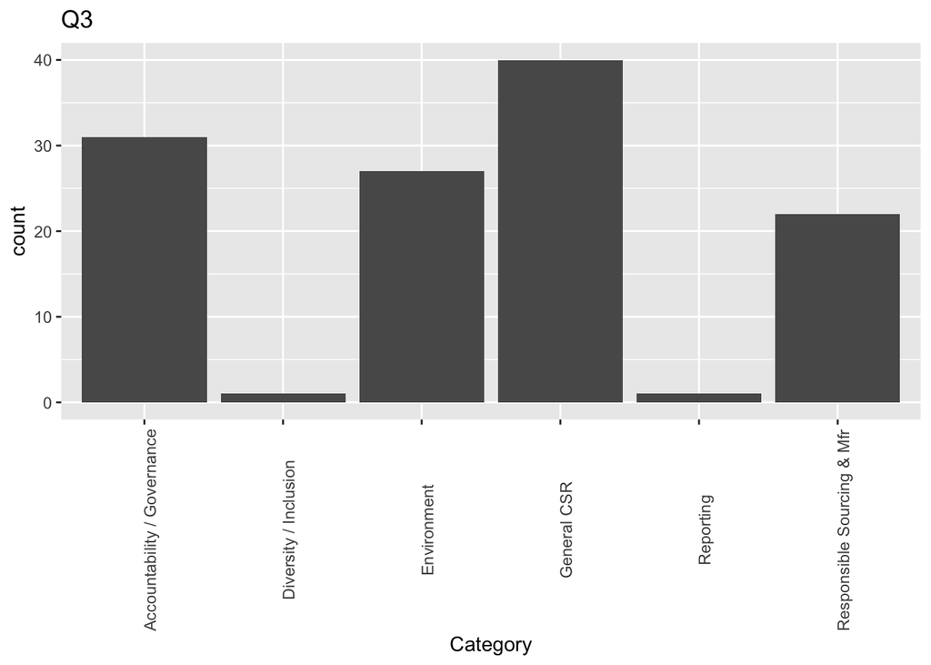

```r
Category_RFPs %>% ggplot() +
  geom_col(aes(x = Category, y = count)) +
  theme(axis.text.x = element_text(angle = 90)) +
  ggtitle("Q3")##creates bar graph for Category RFPs
```

Each quarter can be graphed by simply changing the data used to create the bargraph.

## RFP Regional Analysis

Same goes for the regional analysis:

```r
Region_RFPs <- group_by(RFPs3, Region) %>% summarize(count=n()) %>% arrange(desc(count))
Region_RFPs ## gives Region count of RFPs
```

```
## # A tibble: 3 x 2
##   Region   count
##   <chr>    <int>
## 1 EMEA        55
## 2 Americas    48
## 3 APJ         19
```

```r
Region_RFPs %>% mutate(percentage = count/sum(count)*100) ##adds %
```

```
## # A tibble: 3 x 3
##   Region   count percentage
##   <chr>    <int>      <dbl>
## 1 EMEA        55       45.1
## 2 Americas    48       39.3
## 3 APJ         19       15.6
```

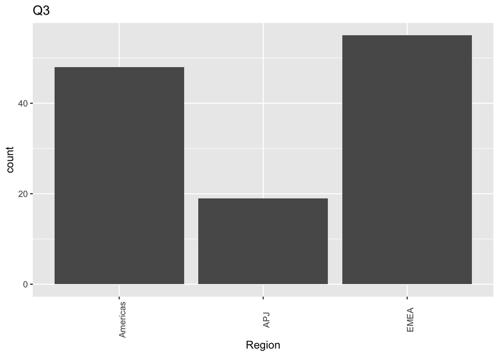

```r
Region_RFPs %>% ggplot() +
  geom_col(aes(x = Region, y = count)) +
  theme(axis.text.x = element_text(angle = 90)) +
  ggtitle("Q3")##creates bar graph for Category RFPs
```

## RFP Escalation Analysis (RFP only)

Escalations are for RFPs only, and designates what kind of oversight the RFP had during the engagement. (1 = Student contracters, 2 = Subject Matter Experts, 3 = Head of department, 4 = Account Executive)

```r
Escalation_RFPs <- group_by(RFPs3, Escalation) %>% summarize(count=n()) %>% arrange(desc(count))
Escalation_RFPs ##gives Escalation count of RFPs
```

```
## # A tibble: 4 x 2
##   Escalation count
##   <chr>      <int>
## 1 1             72
## 2 2             31
## 3 3             18
## 4 <NA>           1
```

# Text Mining

```r
taglist <- "Book2.xlsx"
listtags <- read_excel(taglist, col_names = TRUE)
listtags$Tags<-tolower(listtags$Tags)
RFPs3$Tags<-tolower(RFPs3$Tags)

tags <- c(listtags)
tags
```

```
## $Tags
##  [1] "cdp"
##  [2] "csr goals"
##  [3] "csr report"
##  [4] "ecovadis"
##  [5] "gri"
##  [6] "audits"
##  [7] "bribery/corruption"
##  [8] "certifications"
##  [9] "coc"
## [10] "coc pushback"
## [11] "code of conduct"
## [12] "esg"
## [13] "ehs"
## [14] "health"
```

[output cut: 56 more lines]

```r
GenCSR <- filter(RFPs3, Category == "General CSR") %>%
  select(Tags)
GenCSR <- c(GenCSR)
GenCSR <- as.data.frame(GenCSR)
GCSRtagcount <- sapply(GenCSR, function(x) {
  sapply(tags[["Tags"]], function(y) {
    sum(grepl(y,x))
  })
})


AccountGov <- filter(RFPs3, Category == "Accountability / Governance") %>%
  select(Tags)
AG <- c(AccountGov)
AG <- as.data.frame(AG)
AGtagcount <- sapply(AG, function(x) {
  sapply(tags[["Tags"]], function(y) {
    sum(grepl(y,x))
  })
})
AGtagcount
```

```
##                                       Tags
## cdp                                      0
## csr goals                                0
## csr report                               0
## ecovadis                                 0
## gri                                      0
## audits                                   6
## bribery/corruption                       7
## certifications                           3
## coc                                      3
## coc pushback                             0
## code of conduct                          7
## esg                                      2
## ehs                                      9
## health                                   5
## iso 9001                                 4
## iso 14001                                6
## iso 50001                                2
## ohsas 18001                              2
## permits/licenses                         2
## policies/compliance                     14
## rba                                      4
## safety                                   6
## eco-labels                               0
## energy star                              0
## energy use                               0
## environment                              1
## environmental datasheets                 0
## epeat                                    0
## ghg emissions                            0
## life cycle assessment                    0
## shipping                                 0
## logistics                                0
## multipack                                0
## packaging                                0
## product compliance                       0
## rare earth                               0
## recycling/closed loop                    1
## rohs/reach                               0
## svhc                                     0
```

[output cut: 16 more lines]

```
## human rights & labor                     3
## human trafficking                        0
## living wage                              0
## process chemicals                        0
## ser report                               0
## supplier diversity                       0
## supply chain                             0
## supply chain security/risk/resilience    0
## risk                                     0
## resilience                               0
## awards/recognition                       0
## giving                                   0
## executive briefing center                0
## ebc                                      0
## win                                      0
```

```r
Enviro <- filter(RFPs3, Category == "Environment")%>%
  select(Tags)
EV <- c(Enviro)
EV <- as.data.frame(EV)
EVtagcount <- sapply(EV, function(x) {
  sapply(tags[["Tags"]], function (y) {
    sum(grepl(y, x))
  })
})
EVtagcount
```

```
##                                       Tags
## cdp                                      0
## csr goals                                0
## csr report                               0
## ecovadis                                 0
## gri                                      0
## audits                                   0
## bribery/corruption                       0
## certifications                           0
## coc                                      0
## coc pushback                             0
## code of conduct                          0
## esg                                      0
## ehs                                      2
## health                                   0
## iso 9001                                 0
## iso 14001                                0
## iso 50001                                0
## ohsas 18001                              0
## permits/licenses                         0
## policies/compliance                      2
## rba                                      0
## safety                                   0
## eco-labels                               0
## energy star                              1
## energy use                               1
## environment                              5
## environmental datasheets                 4
## epeat                                    3
## ghg emissions                            1
## life cycle assessment                    0
## shipping                                 4
## logistics                                0
## multipack                                0
## packaging                                4
## product compliance                       3
## rare earth                               1
## recycling/closed loop                    3
## rohs/reach                              11
## svhc                                     4
```

[output cut: 16 more lines]

```
## human rights & labor                     1
## human trafficking                        0
## living wage                              0
## process chemicals                        0
## ser report                               0
## supplier diversity                       0
## supply chain                             0
## supply chain security/risk/resilience    0
## risk                                     0
## resilience                               0
## awards/recognition                       0
## giving                                   0
## executive briefing center                0
## ebc                                      0
## win                                      0
```

```r
RespMfr <- filter(RFPs, Category == "Responsible Sourcing & Mfr")%>%
  select(Tags)
RMfr <- c(RespMfr)
RMfr <- as.data.frame(RMfr)
RMfrtagcount <- sapply(RMfr, function(x) {
  sapply(tags[["Tags"]], function(y) {
    sum(grepl(y,x))
  })
})
RMfrtagcount
```

```
##                                       Tags
## cdp                                      0
## csr goals                                0
## csr report                               0
## ecovadis                                 0
## gri                                      0
## audits                                   1
## bribery/corruption                       0
## certifications                           0
## coc                                      0
## coc pushback                             0
## code of conduct                          0
## esg                                      0
## ehs                                      0
## health                                   0
## iso 9001                                 0
## iso 14001                                0
## iso 50001                                0
## ohsas 18001                              0
## permits/licenses                         0
## policies/compliance                      2
## rba                                      0
## safety                                   0
## eco-labels                               0
## energy star                              0
## energy use                               0
## environment                              0
## environmental datasheets                 0
## epeat                                    0
## ghg emissions                            0
## life cycle assessment                    0
## shipping                                 0
## logistics                                0
## multipack                                0
## packaging                                0
## product compliance                       0
## rare earth                               2
## recycling/closed loop                    0
## rohs/reach                               0
## svhc                                     0
```

[output cut: 16 more lines]

```
## human rights & labor                     0
## human trafficking                        0
## living wage                              0
## process chemicals                        0
## ser report                               0
## supplier diversity                       0
## supply chain                             0
## supply chain security/risk/resilience    0
## risk                                     0
## resilience                               0
## awards/recognition                       0
## giving                                   0
## executive briefing center                0
## ebc                                      0
## win                                      0
```

```r
Repor <- filter(RFPs, Category == "Reporting")%>%
  select(Tags) %>%
  c() %>%
  as.data.frame()
Reportagcount <- sapply(Repor, function(x) {
  sapply(tags[["Tags"]], function(y) {
    sum(grepl(y,x))
  })
})
Reportagcount
```

```
##                                       Tags
## cdp                                      0
## csr goals                                0
## csr report                               0
## ecovadis                                 0
## gri                                      0
## audits                                   0
## bribery/corruption                       0
## certifications                           0
## coc                                      0
## coc pushback                             0
## code of conduct                          0
## esg                                      0
## ehs                                      0
## health                                   0
## iso 9001                                 0
## iso 14001                                0
## iso 50001                                0
## ohsas 18001                              0
## permits/licenses                         0
## policies/compliance                      0
## rba                                      0
## safety                                   0
## eco-labels                               0
## energy star                              0
## energy use                               0
## environment                              0
## environmental datasheets                 0
## epeat                                    0
## ghg emissions                            0
## life cycle assessment                    0
## shipping                                 0
## logistics                                0
## multipack                                0
## packaging                                0
## product compliance                       0
## rare earth                               0
## recycling/closed loop                    0
## rohs/reach                               0
## svhc                                     0
```

[output cut: 16 more lines]

```
## human rights & labor                     0
## human trafficking                        0
## living wage                              0
## process chemicals                        0
## ser report                               0
## supplier diversity                       0
## supply chain                             0
## supply chain security/risk/resilience    0
## risk                                     0
## resilience                               0
## awards/recognition                       0
## giving                                   0
## executive briefing center                0
## ebc                                      0
## win                                      0
```

```r
DandI <- filter(RFPs, Category == "Diversity / Inclusion") %>%
  select(Tags) %>%
  c() %>%
  as.data.frame()
DandItagcount <- sapply(Repor, function(x) {
  sapply(tags[["Tags"]], function(y) {
    sum(grepl(y,x))
  })
})
DandItagcount
```

```
##                                       Tags
## cdp                                      0
## csr goals                                0
## csr report                               0
## ecovadis                                 0
## gri                                      0
## audits                                   0
## bribery/corruption                       0
## certifications                           0
## coc                                      0
## coc pushback                             0
## code of conduct                          0
## esg                                      0
## ehs                                      0
## health                                   0
## iso 9001                                 0
## iso 14001                                0
## iso 50001                                0
## ohsas 18001                              0
## permits/licenses                         0
## policies/compliance                      0
## rba                                      0
## safety                                   0
## eco-labels                               0
## energy star                              0
## energy use                               0
## environment                              0
## environmental datasheets                 0
## epeat                                    0
## ghg emissions                            0
## life cycle assessment                    0
## shipping                                 0
## logistics                                0
## multipack                                0
## packaging                                0
## product compliance                       0
## rare earth                               0
## recycling/closed loop                    0
## rohs/reach                               0
## svhc                                     0
```

[output cut: 16 more lines]

```
## human rights & labor                     0
## human trafficking                        0
## living wage                              0
## process chemicals                        0
## ser report                               0
## supplier diversity                       0
## supply chain                             0
## supply chain security/risk/resilience    0
## risk                                     0
## resilience                               0
## awards/recognition                       0
## giving                                   0
## executive briefing center                0
## ebc                                      0
## win                                      0
```

Each category should be scrubbed for the tags that are most relevent. Once the counts have been aranged, export data into an excel sheet for further analysis and graph making.

## creates a new excel sheet with the tags in their each new sheet

```r
list_of_tags <- list("GenCSRtags" = GCSRtagcount,"Envtags" = EVtagcount, "AGtags" = AGtagcount, "RMtags" = RMfrtagcount, "Rtags" = Reportagcount, "RFPanalysis" = RFP_analysis)
write.xlsx(list_of_tags, file = "q3TAGdata.xlsx")
```

```
## Note: zip::zip() is deprecated, please use zip::zipr() instead
```

Done!